# ĐỒ ÁN CUỐI KỲ - XỬ LÝ SỐ LIỆU THỐNG KÊ

20280071 - Nguyễn Tiến Phong 21110383 - Cao Minh Sơn

# PHÂN TÍCH VÀ XỬ LÝ SỐ LIỆU HÀNH VI KHÁCH HÀNG TRỰC TUYẾN DỰA TRÊN DỮ LIỆU CLICKSTREAM

# Đọc dữ liệu

```r
library(ggplot2)
library(tidyselect)
library(dplyr)
library(rlang)
library(tidyverse)
library(janitor)
library(nycflights13)
library(tinytex)
library(scales)
```

```r
data <- read.csv(file ="e-shop clothing 2008.csv", sep = ";") |> clean_names()
```

# Khám phá dữ liệu

```r
# Kiểm tra giá trị null
sum(is.na(data))
```

```
## [1] 0
```

#### Dựa trên giá trị trong cột page_1_main_category, tạo một cột mới có tên page1_label dán nhãn các danh mục:

1: Trousers

2: Skirts

3: Blouses

4: Sale

```r
# Tạo cột mới page1_label chứa các nhãn của danh mục
data <- data |>
  mutate(
    page1_label = case_when(
      page_1_main_category == 1 ~ "1 - trousers",
      page_1_main_category == 2 ~ "2 - skirts",
      page_1_main_category == 3 ~ "3 - blouses",
      page_1_main_category == 4 ~ "4 - sale",
      TRUE ~ "other"
    )
  )
```

#### Biểu đồ dưới đây thể hiện số lượt click vào các sản phẩm trong từng danh mục. Mỗi cột đại diện cho một danh mục sản phẩm, với chiều cao của cột tương ứng với số lượt click vào các sản phẩm trong danh mục đó.

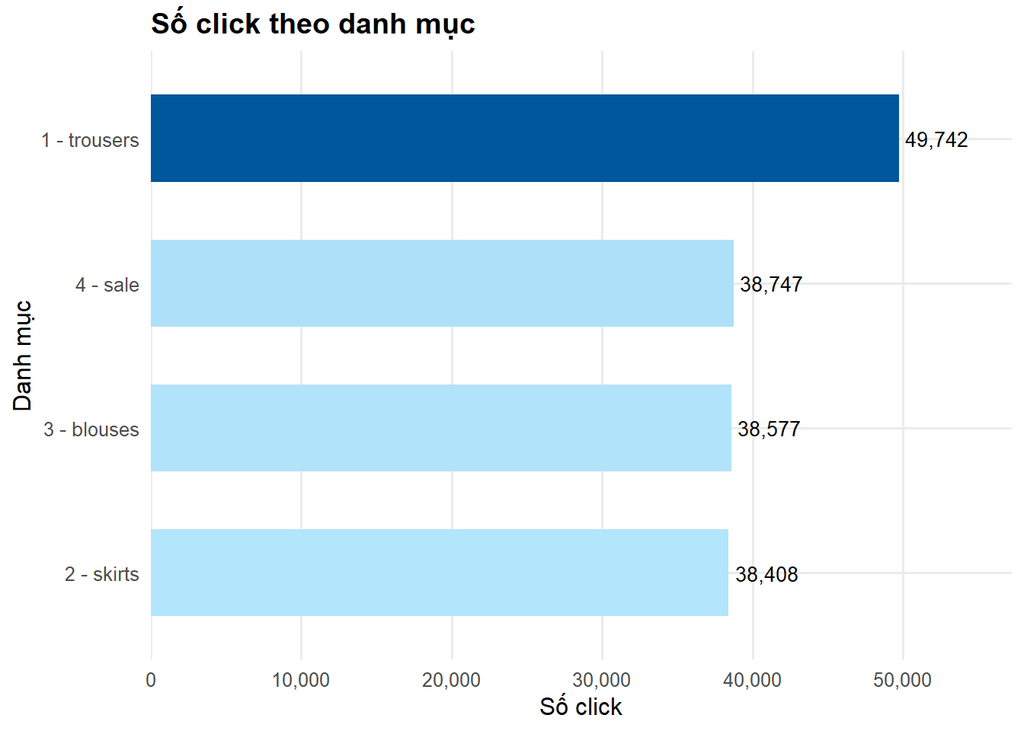

```r
# Biểu đồ số lượt click theo danh mục
data |>
  count(page1_label) |>
  mutate(
    value = n,
    page1_label = reorder(page1_label, value)
  ) |>
  ggplot(aes(
    x = page1_label,
    y = value,
    fill = value
  )) +
  geom_col(width = 0.6) +
  geom_text(
    aes(label = comma(value)),
    hjust = -0.1,
    size = 3.5
  ) +
  coord_flip() +
  scale_fill_gradient(
    low = "#B3E5FC",
    high = "#01579B",
    guide = "none"
  ) +
  scale_y_continuous(
    labels = comma,
    expand = expansion(mult = c(0, 0.15))
  ) +
  labs(
    title = "Số click theo danh mục",
    x = "Danh mục",
    y = "Số click"
  ) +
  theme_minimal(base_size = 12) +
  theme(
    plot.title = element_text(face = "bold"),
    panel.grid.minor = element_blank()
  )
```

#### Giải thích biểu đồ:

- Trục X: Số lượt click vào các sản phẩm trong từng danh mục.
- Trục Y: Các danh mục sản phẩm được phân loại theo cột page1_label (ví dụ: Trousers, Skirts, Blouses, Sale).

# Mục tiêu 1: Mô tả tổng quan hành vi người dùng dựa trên dữ liệu clickstream (trong từng phiên truy cập).

#### Bảng click_per_session cung cấp cái nhìn tổng quan về số lần click trong mỗi phiên và liệu có sản phẩm giảm giá nào được người dùng quan tâm trong phiên đó hay không (SALE hay NON-SALE)

```r
# Bảng thống kê số click theo mỗi session
click_per_session <- data |>
  group_by(session_id) |>
  summarise(
    n_clicks = n(),
    sale = any(page_1_main_category == 4),
    .groups = "drop"
  )

click_per_session
```

```
## # A tibble: 24,026 × 3
##    session_id n_clicks sale
##         <int>    <int> <lgl>
##  1          1        9 TRUE
##  2          2       10 TRUE
##  3          3        6 TRUE
##  4          4        4 FALSE
##  5          5        1 FALSE
##  6          6        5 FALSE
##  7          7       11 TRUE
##  8          8        9 FALSE
##  9          9        3 FALSE
## 10         10        5 FALSE
## # ℹ 24,016 more rows
```

## Thống kê mô tả:

```r
# Bảng thống kê mô tả cho số lần click
click_per_session |>
  summarise(
    `Số session`        = n(),
    `Mean số click`     = mean(n_clicks),
    `Median số click`   = median(n_clicks),
    `Độ lệch chuẩn`     = sd(n_clicks),
    `Min_click`      = min(n_clicks),
    `Q1 (25%)`          = quantile(n_clicks, 0.25),
    `Q3 (75%)`          = quantile(n_clicks, 0.75),
    `Max_click`      = max(n_clicks)
  ) |>
  pivot_longer(
    cols = everything(),
  )
```

```
## # A tibble: 8 × 2
##   name               value
##   <chr>              <dbl>
## 1 Số session      24026
## 2 Mean số click       6.89
## 3 Median số click     4
## 4 Độ lệch chuẩn       9.00
## 5 Min_click           1
## 6 Q1 (25%)            2
## 7 Q3 (75%)            8
## 8 Max_click         195
```

#### Biểu đồ phân phối (histogram) thể hiện số lần click trong mỗi phiên (session).

Biểu đồ này đã được chuyển đổi sang dạng logarit (log10) để làm cho sự phân bố của số lần click trở nên rõ ràng hơn và giúp phát hiện các xu hướng.

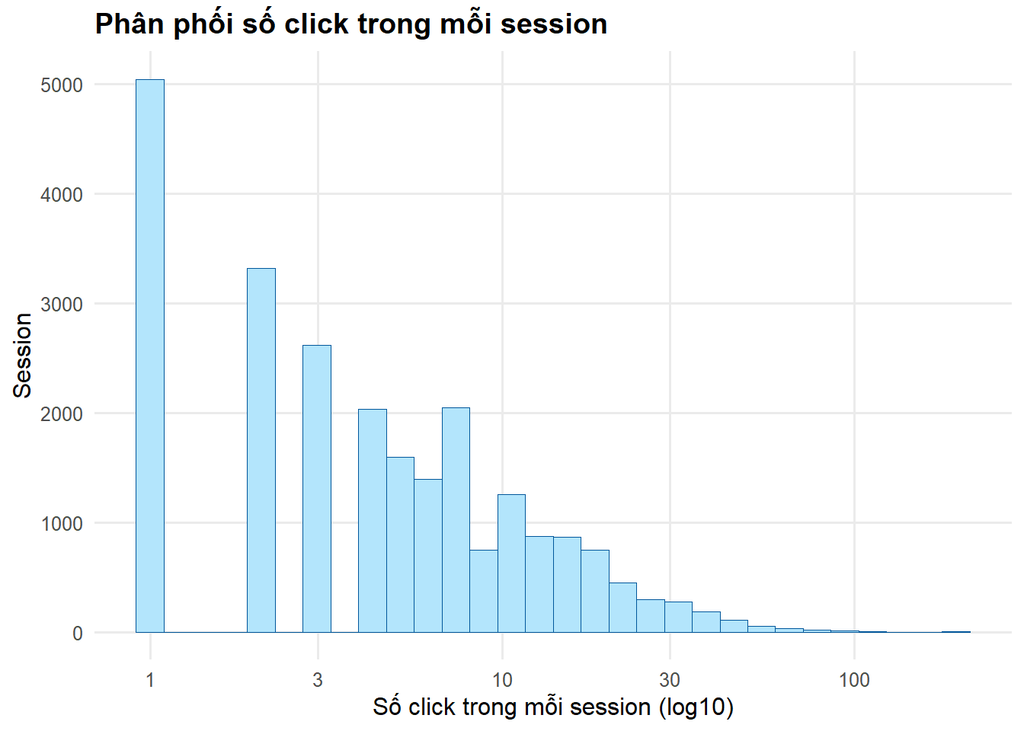

```r
ggplot(click_per_session, aes(x = n_clicks)) +
  geom_histogram(
    bins = 30,
    fill = "#B3E5FC",
    color = "#01579B",
    linewidth = 0.3
  ) +
  scale_x_log10(
    breaks = c(1, 3, 10, 30, 100),
    labels = comma
  ) +
  labs(
    title = "Phân phối số click trong mỗi session",
    x = "Số click trong mỗi session (log10)",
    y = "Session"
  ) +
  theme_minimal(base_size = 12) +
  theme(
    plot.title = element_text(face = "bold"),
    panel.grid.minor = element_blank()
  )
```

#### Giải thích biểu đồ:

- Trục X: Số click trong mỗi session (log10) thể hiện logarit của số lần click trong mỗi phiên. Việc sử dụng logarit (log10) giúp làm mượt phân phối của dữ liệu, đặc biệt là với những phiên có số lần click rất lớn.
- Trục Y: Số session thể hiện số phiên (sessions) với một lượng click trong một phạm vi nhất định

```r
click_per_session |>
  group_by(sale) |>
  summarise(
    n_sessions = n(),
    mean_clicks = mean(n_clicks),
    median_clicks = median(n_clicks),
    sd_clicks = sd(n_clicks),
    min_clicks = min(n_clicks),
    max_clicks = max(n_clicks)
  )
```

```
## # A tibble: 2 × 7
##   sale  n_sessions mean_clicks median_clicks sd_clicks min_clicks max_clicks
##   <lgl>      <int>       <dbl>         <dbl>     <dbl>      <int>      <int>
## 1 FALSE      14834        4.71             3      6.25          1        192
## 2 TRUE        9192       10.4              7     11.3           1        195
```

# Mục tiêu 2: **Khám phá và So sánh mức độ tương tác giữa các nhóm phiên**

#### Một session được coi là sale nếu có ít nhất 1 click vào sản phẩm sale.

```r
clicks_sale <- click_per_session$n_clicks[
  click_per_session$sale == TRUE
]

clicks_nonsale <- click_per_session$n_clicks[
  click_per_session$sale == FALSE
]
```

```r
length(clicks_sale)
```

```
## [1] 9192
```

```r
length(clicks_nonsale)
```

```
## [1] 14834
```

#### Biểu đồ phân phối (Histogram) so sánh số lần click giữa hai nhóm: Sale và Non-sale.

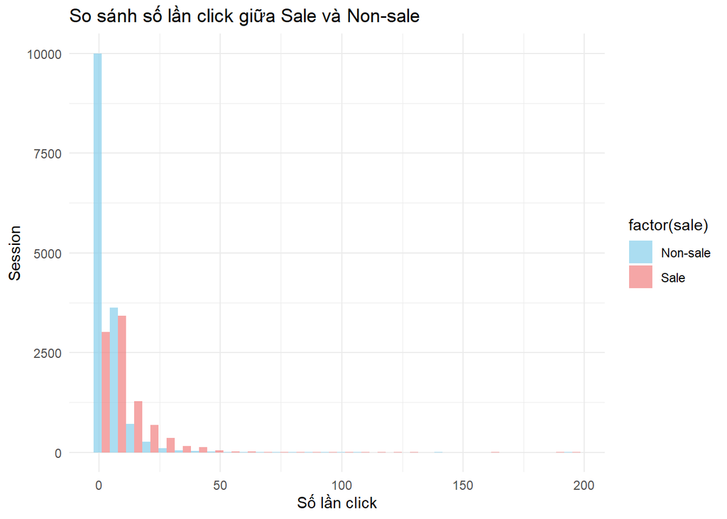

```r
# Histogram so sánh số lần click giữa Sale và Non-sale
ggplot(click_per_session, aes(x = n_clicks, fill = factor(sale))) +
  geom_histogram(position = "dodge", bins = 30, alpha = 0.7) +
  labs(title = "So sánh số lần click giữa Sale và Non-sale",
       x = "Số lần click", y = "Session") +
  scale_fill_manual(values = c("skyblue", "lightcoral"), labels = c("Non-sale", "Sale")) +
  theme_minimal()
```

#### Giải thích biểu đồ:

- Trục X: Số lần click thể hiện số lần click trong mỗi phiên (session). Các phiên có số lần click thấp sẽ có giá trị gần 0, trong khi các phiên có số lần click cao sẽ dịch chuyển ra phía bên phải của trục.
- Trục y: Số phiên (Session) thể hiện số lượng phiên có số click rơi vào trong từng bin. Mỗi bin là một khoảng giá trị số lần click.

#### Boxplot so sánh số lần click giữa các phiên xem sản phẩm SALE và không xem sản phẩm SALE.

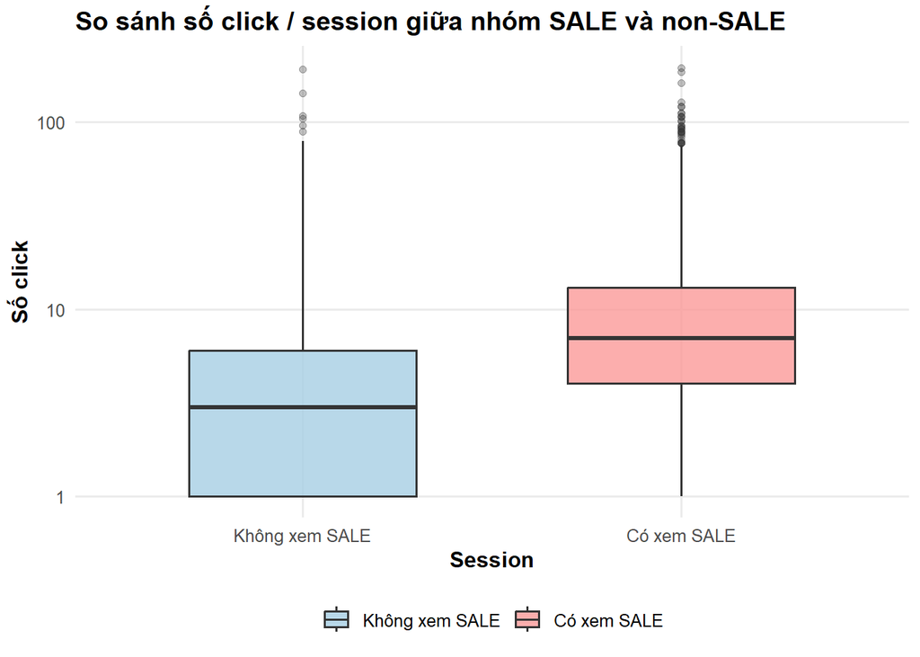

```r
# Boxplot thể hiện số click
ggplot(click_per_session, aes(x = sale, y = n_clicks, fill = sale)) +
  geom_boxplot(
    width = 0.6,
    alpha = 0.8,
    outlier.alpha = 0.3
  ) +
  scale_y_log10() +
  scale_fill_manual(
    values = c("FALSE" = "#A6CEE3", "TRUE" = "#FB9A99"),
    labels = c("FALSE" = "Không xem SALE", "TRUE" = "Có xem SALE"),
    name = NULL
  ) +
  scale_x_discrete(
    labels = c("FALSE" = "Không xem SALE", "TRUE" = "Có xem SALE")
  ) +
  labs(
    title = "So sánh số click / session giữa nhóm SALE và non-SALE",
    x = "Session",
    y = "Số click"
  ) +
  theme_minimal(base_size = 12) +
  theme(
    plot.title = element_text(face = "bold"),
    axis.title = element_text(face = "bold"),
    legend.position = "bottom",
    panel.grid.minor = element_blank()
  )
```

#### Giải thích biểu đồ:

- Trục X: Khối “Không xem SALE” (màu xanh dương): Đại diện cho nhóm người dùng không tương tác với sản phẩm giảm giá (non-Sale). Khối “Có xem SALE” (màu đỏ): Đại diện cho nhóm người dùng đã tương tác với sản phẩm giảm giá (Sale).
- Trục Y: Số click thể hiện số lần click trong mỗi phiên, tức là mỗi điểm trên trục Y đại diện cho số lần click trong một phiên.
- Boxplot cho thấy sự khác biệt về mức độ tương tác giữa các nhóm session, đồng thời tồn tại nhiều giá trị ngoại lai, củng cố việc lựa chọn các phương pháp suy luận phi tham số.

# Mục tiêu 3: **Đánh giá ý nghĩa thống kê và ý nghĩa thực tiễn thông qua phương pháp kiểm định**

## Permutation test:

- Giả thuyết $H_0$: phân phối số click giữa hai nhóm session là như nhau, tương đương với chênh lệch trung bình bằng 0.
- Giả thuyết đối ($H_1$): tồn tại sự khác biệt trong phân phối số click giữa hai nhóm session.

```r
perm_test_mean <- function(x, y, R = 5000) {
  t_obs <- mean(x) - mean(y)
  z <- c(x, y)
  n_x <- length(x)

  t_perm <- replicate(R, {
    z_perm <- sample(z)
    mean(z_perm[1:n_x]) - mean(z_perm[(n_x + 1):length(z)])
  })

  p_value <- mean(abs(t_perm) >= abs(t_obs))

  list(
    t_obs = t_obs,
    p_value = p_value,
    perm_stat = t_perm
  )
}
```

```r
set.seed(2026)
res_perm <- perm_test_mean(
  x = click_per_session$n_clicks[click_per_session$sale == TRUE],
  y = click_per_session$n_clicks[click_per_session$sale == FALSE]
)
```

#### Histogram thể hiện phân phối của các permutation statistics được tạo ra trong quá trình Permutation Test.

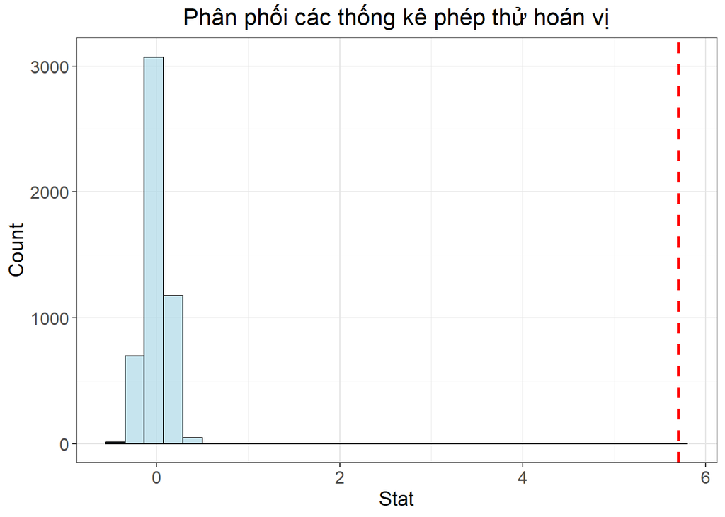

```r
ggplot(data.frame(stat = res_perm$perm_stat), aes(x = stat)) +
  geom_histogram(bins = 30, fill = "lightblue", color = "black", alpha = 0.7) +
  geom_vline(xintercept = res_perm$t_obs, linetype = "dashed", color = "red", size = 1) +
  theme_bw() +
  labs(title = "Phân phối các thống kê phép thử hoán vị",
       x = "Stat",
       y = "Count") +
  theme(axis.text = element_text(size = 12),
        axis.title = element_text(size = 14),
        plot.title = element_text(size = 16, hjust = 0.5)) +
  theme(panel.grid.major = element_line(color = "gray90", size = 0.5))
```

#### Giải thích biểu đồ:

- Trục X: Stat thể hiện các giá trị permutation statistics (tức là giá trị thống kê được tính sau mỗi lần hoán đổi) từ kết quả của phép kiểm định hoán vị. Các giá trị này cho phép kiểm tra sự phân phối của các số liệu ngẫu nhiên khi hoán đổi các giá trị trong hai nhóm.
- Trục Y: Count thể hiện số lượng (count) các lần hoán đổi có giá trị thống kê (permutation statistic) trong mỗi khoảng giá trị trên trục X.
- Vline (Đường đỏ): đánh dấu giá trị thống kê quan sát được trong dữ liệu gốc. Đường này thể hiện giá trị trung bình thực tế giữa hai nhóm đang kiểm tra trong Permutation Test.

# Bootstrap test:

## Trung bình 1 nhóm:

```r
boot_mean <- function(x, R = 2000) {
  boot_stat <- replicate(R, {
    mean(sample(x, replace = TRUE))
  })

  list(
    boot_stat = boot_stat,
    mean_boot = mean(boot_stat),
    ci = quantile(boot_stat, c(0.025, 0.975))
  )
}
```

```r
set.seed(2026)
boot_all <- boot_mean(click_per_session$n_clicks)
boot_all$ci
```

```
##     2.5%    97.5%
## 6.768198 6.997230
```

#### Histogram thể hiện phân phối của trung bình số click trong dữ liệu, được tính bằng phương pháp Bootstrap.

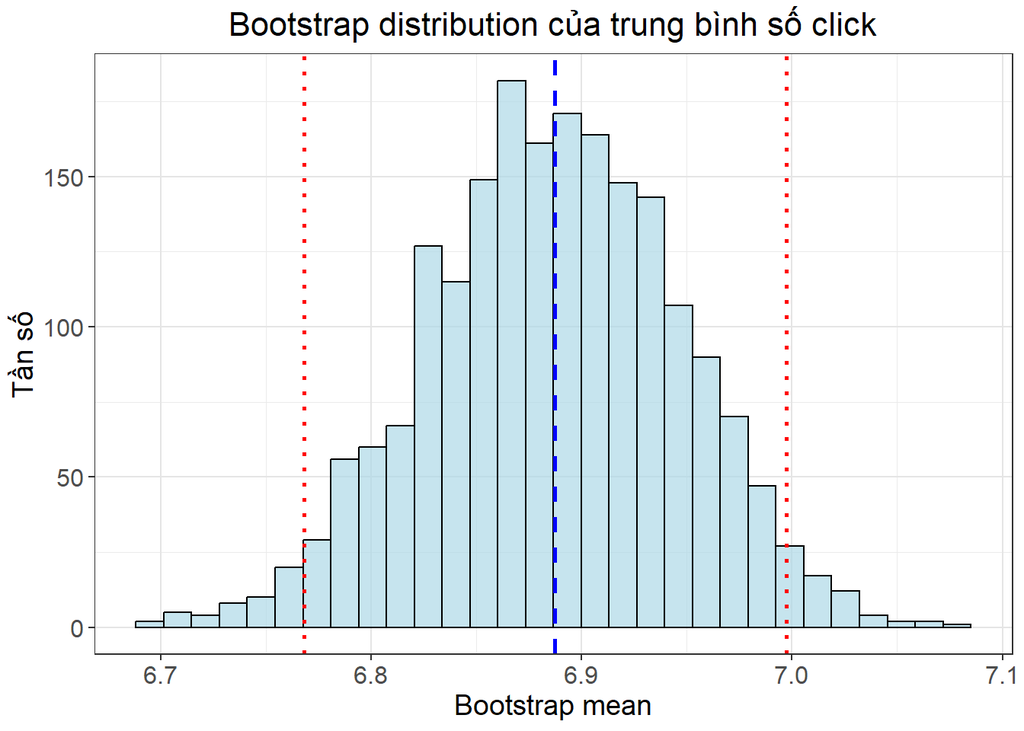

```r
ggplot(data.frame(stat = boot_all$boot_stat), aes(x = stat)) +
  geom_histogram(bins = 30, fill = "lightblue", color = "black", alpha = 0.7) +
  geom_vline(xintercept = mean(click_per_session$n_clicks), linetype = "dashed", color = "blue", size = 1) +
  geom_vline(xintercept = boot_all$ci, linetype = "dotted", color = "red", size = 1) +
  labs(
    x = "Bootstrap mean",
    y = "Tần số",
    title = "Bootstrap distribution của trung bình số click"
  ) +
  theme_bw() +
  theme(axis.text = element_text(size = 12),
        axis.title = element_text(size = 14),
        plot.title = element_text(size = 16, hjust = 0.5)) +
  theme(panel.grid.major = element_line(color = "gray90", size = 0.5))
```

#### Giải thích biểu đồ:

- Trục X: Bootstrap mean thể hiện trung bình số click của các mẫu bootstrap. Đây là giá trị trung bình được tính toán từ mỗi mẫu ngẫu nhiên được lấy từ dữ liệu gốc.
- Trục Y: Tần số (Count) thể hiện số lần xuất hiện của mỗi giá trị bootstrap mean. Nếu nhiều mẫu bootstrap có cùng trung bình gần giống nhau, thì cột trên biểu đồ sẽ cao hơn.
- Đường màu xanh dương đánh dấu giá trị trung bình thực tế của số lần click trong dữ liệu gốc. Đây là trung bình số lần click trong các phiên mua sắm, được tính từ toàn bộ dữ liệu.
- Các đường dọc đỏ đánh dấu khoảng tin cậy 95% của trung bình số click, được tính từ phân phối của các giá trị trung bình trong các mẫu bootstrap. Khoảng tin cậy này cho bạn biết phạm vi mà trung bình số click có thể nằm trong đó với độ tin cậy 95%.

### Chêch lệch trung bình:

#### Sử dụng Bootstrap để ước lượng khoảng tin cậy cho sự khác biệt trung bình số click giữa hai nhóm: Nhóm A (không xem SALE) và Nhóm B (có xem SALE).

```r
boot_diff_mean <- function(x, y, R = 2000) {
  boot_stat <- replicate(R, {
    mean(sample(x, replace = TRUE)) -
      mean(sample(y, replace = TRUE))
  })

  list(
    boot_stat = boot_stat,
    ci = quantile(boot_stat, c(0.025, 0.975))
  )
}
```

```r
x <- click_per_session$n_clicks[click_per_session$sale == TRUE]   # Nhóm B
y <- click_per_session$n_clicks[click_per_session$sale == FALSE]  # Nhóm A

set.seed(2026)
boot_res <- boot_diff_mean(x , y, R = 2000)
boot_res$ci
```

```
##     2.5%    97.5%
## 5.450200 5.942503
```

Khoảng tin cậy cho sự khác biệt trung bình này cho thấy sự khác biệt giữa số lần click của hai nhóm là có ý nghĩa và có thể tin cậy trong phạm vi được ước tính từ 5.45 đến 5.94.

#### Histogram thể hiện phân phối của sự khác biệt trung bình giữa hai nhóm: Nhóm Sale và Nhóm Non-sale.

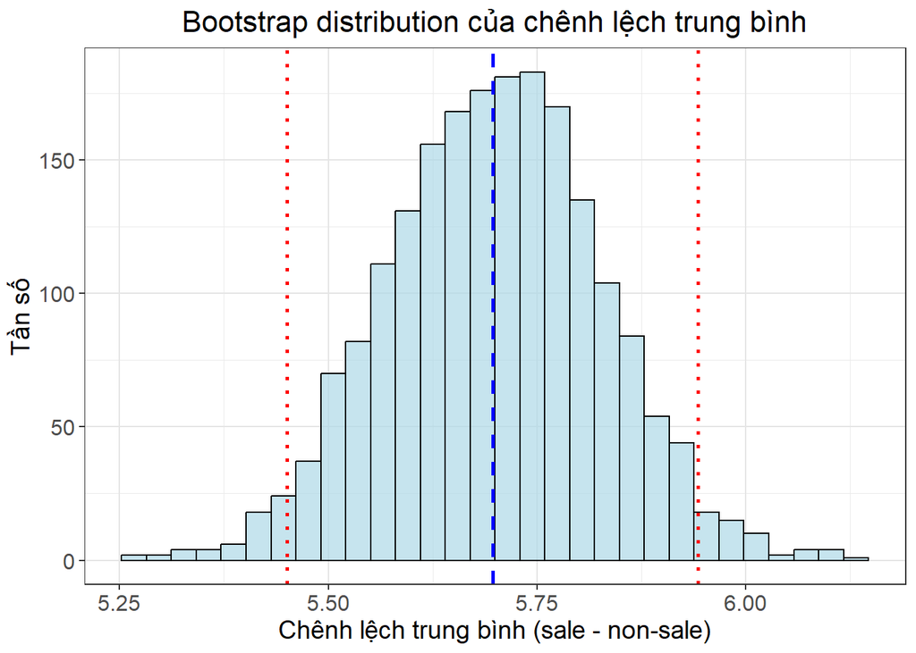

```r
ggplot(data.frame(diff = boot_res$boot_stat), aes(x = diff)) +
  geom_histogram(bins = 30, fill = "lightblue", color = "black", alpha = 0.7) +
  geom_vline(xintercept = mean(x) - mean(y), linetype = "dashed", color = "blue", size = 1) +
  geom_vline(xintercept = boot_res$ci, linetype = "dotted", color = "red", size = 1) +
  labs(
    x = "Chênh lệch trung bình (sale - non-sale)",
    y = "Tần số",
    title = "Bootstrap distribution của chênh lệch trung bình"
  ) +
  theme_bw() +
  theme(axis.text = element_text(size = 12),
        axis.title = element_text(size = 14),
        plot.title = element_text(size = 16, hjust = 0.5)) +
  theme(panel.grid.major = element_line(color = "gray90", size = 0.5))
```

#### Giải thích biểu đồ:

- Trục X: thể hiện sự khác biệt giữa trung bình số click trong nhóm Sale và Non-sale. Các giá trị trên trục X là các chênh lệch trung bình giữa hai nhóm, được tính từ các mẫu bootstrap.
- Trục Y: thể hiện số lần xuất hiện của mỗi giá trị chênh lệch trung bình trong phân phối bootstrap.
- Đường màu xanh dương thể hiện sự khác biệt trung bình thực tế giữa nhóm Sale và nhóm Non-sale (tính từ dữ liệu gốc).
- Các đường dọc đỏ đánh dấu khoảng tin cậy 95% cho sự khác biệt trung bình từ phân phối bootstrap. Khoảng tin cậy này cho biết phạm vi mà sự khác biệt trung bình có thể nằm trong đó với độ tin cậy 95%.

# Kết luận

Dự án đã đạt được các mục tiêu đề ra, thành công trong việc phân tích hành vi người

dùng qua dữ liệu clickstream và rút ra những kết luận có ý nghĩa thực tiễn về sự khác biệt

trong hành vi tương tác giữa các nhóm session có và không có SALE. Các phương pháp

## Permutation Test

Kết quả permutation test cho chênh lệch trung bình số click giữa hai nhóm cho giá trị

thống kê quan sát lớn và p-value xấp xỉ 0, cho thấy sự khác biệt giữa hai nhóm là có ý

nghĩa thống kê. Điều này cung cấp bằng chứng mạnh để bác bỏ giả thuyết không rằng hai

nhóm có cùng mức click trung bình.

## Bootstrap Test

Bootstrap cung cấp khoảng tin cậy 95% cho trung bình số click trong một phiên truy

cập là từ 6.77 đến 7.00, cho thấy ước lượng trung bình số click là ổn định và có độ tin cậy

cao.

Bootstrap cho chênh lệch trung bình giữa 2 nhóm SALE và non-SALE cho thấy khoảng

tin cậy 95% là [5.45; 5.94], và khoảng này không chứa 0. Điều này củng cố thêm kết luận

rằng nhóm sale có số click trung bình cao hơn nhóm non-sale một cách có ý nghĩa.